# Introduction to Assignment

## Evaluation and model selection

Predict on "unseen" data using the best models obtained in the training phase and evaluate using different metrics.

⚠️ *Best models will be selected when training the models with the actual train data*

```
####################################################################
####################################################################
                        Model 1:
--------------------------------------------------------------------
mean_fit_time      1.415787
accuracy               0.81
recall_macro           0.81
recall_micro           0.81
precision_macro    0.815456
precision_micro        0.81
f1_macro           0.811529
Name: 0, dtype: object


Pipeline:
Pipeline(steps=[('join', <__main__.JoinElement object at 0x7fbabd0fbf70>),
                ('tfidf', TfidfVectorizer()),
                ('k_best',
                 SelectKBest(k=1000,
                             score_func=<function chi2 at 0x7fbbdbf5dc10>)),
                ('MNB', MultinomialNB(alpha=0, fit_prior=False))])


Confusion Matrix:
```

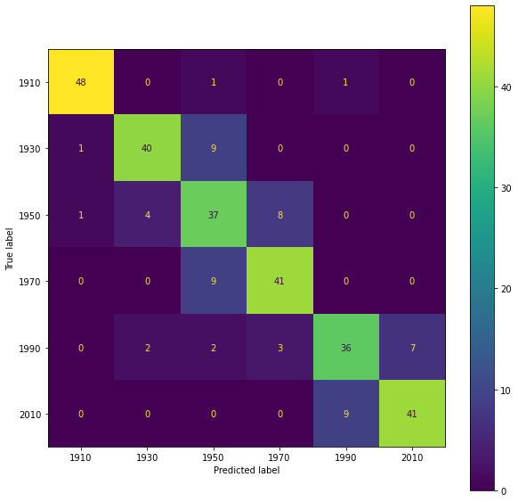

```
####################################################################
####################################################################
                        Model 2:
--------------------------------------------------------------------
mean_fit_time      5.701224
accuracy               0.75
recall_macro           0.75
recall_micro           0.75
precision_macro    0.797489
precision_micro        0.75
f1_macro           0.752323
Name: 1, dtype: object


Pipeline:
Pipeline(steps=[('join', <__main__.JoinElement object at 0x7fbbbbf05ee0>),
                ('tfidf', TfidfVectorizer()),
                ('k_best',
                 SelectKBest(k=1000,
                             score_func=<function chi2 at 0x7fbbdbf5dc10>)),
                ('SVC', SVC(degree=2, kernel='poly'))])


Confusion Matrix:
```

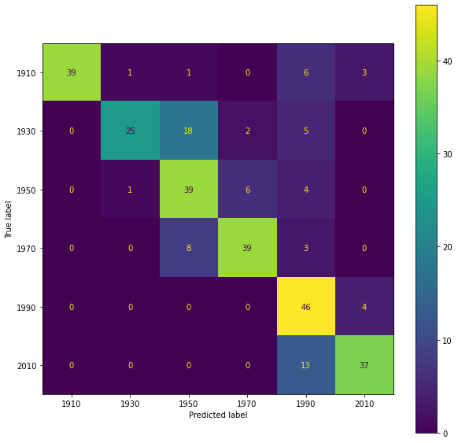

```
####################################################################
####################################################################
                        Model 3:
--------------------------------------------------------------------
mean_fit_time        5.2989
accuracy               0.72
recall_macro           0.72
recall_micro           0.72
precision_macro    0.757277
precision_micro        0.72
f1_macro            0.71807
Name: 2, dtype: object


Pipeline:
Pipeline(steps=[('join', <__main__.JoinElement object at 0x7fbbb97ba0d0>),
                ('tfidf', TfidfVectorizer()),
                ('k_best',
                 SelectKBest(k=1000,
                             score_func=<function chi2 at 0x7fbbdbf5dc10>)),
                ('clf', RandomForestClassifier(n_estimators=200))])


Confusion Matrix:
```

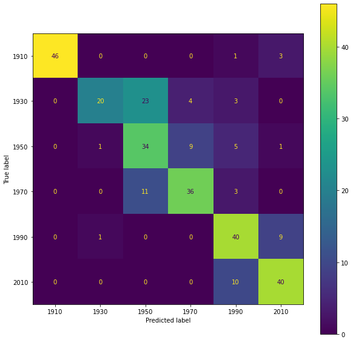

```
####################################################################
####################################################################
                        Model 4:
--------------------------------------------------------------------
mean_fit_time      35.71164
accuracy           0.533333
recall_macro       0.533333
recall_micro       0.533333
precision_macro    0.607048
precision_micro    0.533333
f1_macro           0.544174
Name: 3, dtype: object


Pipeline:
Pipeline(steps=[('word2vec', MeanEmbeddingVectorizer()),
                ('SVC', SVC(degree=2, kernel='linear'))])


Confusion Matrix:
```

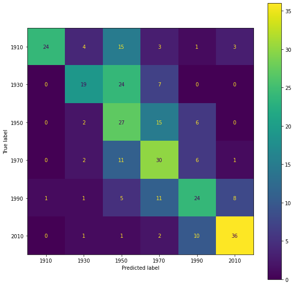

```
####################################################################
####################################################################
                        Model 5:
--------------------------------------------------------------------
mean_fit_time      37.497166
accuracy            0.396667
recall_macro        0.396667
recall_micro        0.396667
precision_macro      0.51096
precision_micro     0.396667
f1_macro            0.384217
Name: 4, dtype: object


Pipeline:
Pipeline(steps=[('word2vec', MeanEmbeddingVectorizer()),
                ('clf', RandomForestClassifier(n_estimators=300))])


Confusion Matrix:
```

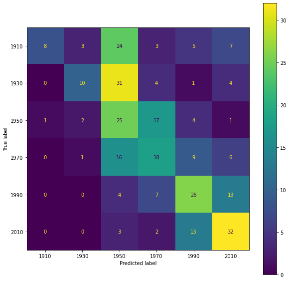

```
####################################################################
####################################################################
                        Model 6:
--------------------------------------------------------------------
mean_fit_time      99.642594
accuracy            0.693333
recall_macro        0.693333
recall_micro        0.693333
precision_macro     0.733468
precision_micro     0.693333
f1_macro            0.698787
Name: 5, dtype: object


Pipeline:
Pipeline(steps=[('doc2vec', Doc2Vectorizer(vector_size=300, window=4)),
                ('SVC', SVC(degree=2, kernel='linear'))])


Confusion Matrix:
```

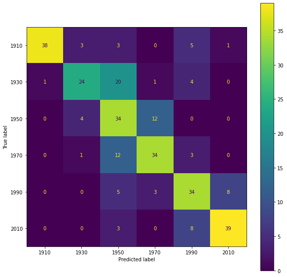

```
####################################################################
####################################################################
                        Model 7:
--------------------------------------------------------------------
mean_fit_time      98.210749
accuracy            0.523333
recall_macro        0.523333
recall_micro        0.523333
precision_macro     0.562907
precision_micro     0.523333
f1_macro             0.51323
Name: 6, dtype: object


Pipeline:
Pipeline(steps=[('doc2vec', Doc2Vectorizer(vector_size=300, window=4)),
                ('clf', RandomForestClassifier(n_estimators=200))])


Confusion Matrix:
```

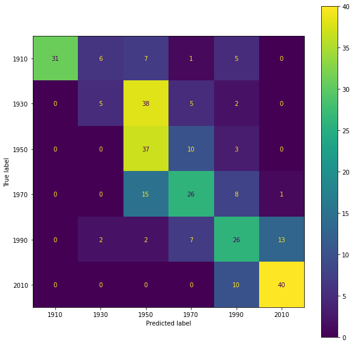

|  | model | mean_fit_time | accuracy | recall_macro | recall_micro | precision_macro | precision_micro | f1_macro | f1_micro | model_definition |
| --- | --- | --- | --- | --- | --- | --- | --- | --- | --- | --- |
| 0 | Model 1 | 1.415787 | 0.810000 | 0.810000 | 0.810000 | 0.815456 | 0.810000 | 0.811529 | 0.810000 | GridSearchCV(cv=5,\n estimator=Pip... |
| 1 | Model 2 | 5.701224 | 0.750000 | 0.750000 | 0.750000 | 0.797489 | 0.750000 | 0.752323 | 0.750000 | GridSearchCV(cv=5,\n estimator=Pip... |
| 2 | Model 3 | 5.298900 | 0.720000 | 0.720000 | 0.720000 | 0.757277 | 0.720000 | 0.718070 | 0.720000 | GridSearchCV(cv=5,\n estimator=Pip... |
| 5 | Model 6 | 99.642594 | 0.693333 | 0.693333 | 0.693333 | 0.733468 | 0.693333 | 0.698787 | 0.693333 | GridSearchCV(cv=5,\n estimator=Pip... |
| 3 | Model 4 | 35.711640 | 0.533333 | 0.533333 | 0.533333 | 0.607048 | 0.533333 | 0.544174 | 0.533333 | GridSearchCV(cv=5,\n estimator=Pip... |
| 6 | Model 7 | 98.210749 | 0.523333 | 0.523333 | 0.523333 | 0.562907 | 0.523333 | 0.513230 | 0.523333 | GridSearchCV(cv=5,\n estimator=Pip... |
| 4 | Model 5 | 37.497166 | 0.396667 | 0.396667 | 0.396667 | 0.510960 | 0.396667 | 0.384217 | 0.396667 | GridSearchCV(cv=5,\n estimator=Pip... |

```python
#add models to be evaluated
models = [
    grid_search_model_1,
    grid_search_model_2,
    grid_search_model_3,
    grid_search_model_4,
    grid_search_model_5,
    grid_search_model_6,
    grid_search_model_7
]

evaluation = pd.DataFrame(columns=["model"
                                   , "mean_fit_time", "accuracy"
                                   , "recall_macro", "recall_micro"
                                   , "precision_macro", "precision_micro"
                                   , "f1_macro", "f1_micro"
                                   , "model_definition"
                                  ])

i = -1 # Ensure that first item is index 0 in the loop
for model_ in models:
    # Yucky method of finding mean fit times:
    i = i +1
    mean_fit_time = cv_results.groupby("Model")["mean_fit_time"].mean()[i]

    # Predict
    preds = model_.best_estimator_.predict(file_contents_test)
    model = cv_results.iloc[model_.best_index_,0]

    # Calculate metrix
    to_append = [
            "Model " + str(i+1),
            mean_fit_time,
            accuracy_score(y_true=targets_test,y_pred=preds),
            #choose micro or macro according to criteria
            recall_score(y_true=targets_test,y_pred=preds, average="macro"),
            recall_score(y_true=targets_test,y_pred=preds, average="micro"),
            precision_score(y_true=targets_test,y_pred=preds, average="macro"),
            precision_score(y_true=targets_test,y_pred=preds, average="micro"),
            f1_score(y_true=targets_test,y_pred=preds, average="macro"),
            f1_score(y_true=targets_test,y_pred=preds, average="micro"),
            model_
            ]

    #Append Metrics
    evaluation_length = len(evaluation)
    evaluation.loc[evaluation_length] = to_append

    # Print results and Confusion Matrix for each model
    print("####################################################################")
    print("####################################################################")
    print("                        Model "+ str(i+1) + ":")
    print("--------------------------------------------------------------------")

    print(evaluation.loc[i, 'mean_fit_time':'f1_macro'])
    print("\n")
    print("Pipeline: ")
    print(model_.best_estimator_)

    print("\n")
    print("Confusion Matrix: ")
    fig, ax = plt.subplots(figsize=(10, 10))
    plot_confusion_matrix(estimator=model_.best_estimator_
                          , X=file_contents_test
                          , y_true=targets_test
                          , ax=ax
                         )
    plt.show()

# Print table of the models compared and sorted:
evaluation.sort_values(by="accuracy", ascending = False)
```

⚠️ *Best models will be selected when training the models with the actual train data*

Main **conclusion**: for unseen data, we would choose to use the estimator from above.

# Conclusion

Some observations:

As often is the case in the fields of science, not all research leads to useable results. We ended up having to remodel our plans several times during this project, including a complete pivot of the datasets.

This did however give us some insight into how larger projects are managed. This also lead us to an interesting path of looking at a relatively obscure language.

Although further works is possible, we reached the conclusion that there is a change in the Icelandic spoken language throughout time, and it is therefore possible to train models that estimates which decade a given speech is from.

Overall we did work with Data-Oriented Programming best practices. We were able to develop a scientific workflow. From the given data, we managed to train a model for prediction with decent results.

# Further Works

As we drilled down this dataset, we kept getting new ideas that we would like to experiment with, and try to gain better insight. Specifically, our next steps would be:

## Predict Different Sources

As it currently stands, we are trying to estimate a decade of speeches from "Althingi". However, the dataset has several other sources of Icelandic; both written and spoken.

We would like to see if it was possible to extend our model to be able to classify the source.

## Treating years as Contious Variables

We are currently treating decades as a class. By discretizing results from a regression algorithm, we think it should be possible to keep some nominal knowledge of the ordering of the years, and thus improving our predictions

## Gaining insight into Explanatory Variables

From our results, it is clear that it is somewhat possible to predict the decades. However, we are still treating the algorithms as "Black Boxes". We would like to dive deeper into the decision treas/boundaries, to see if we can locate what it is that makes the predictions possible. It might be new words introduced, semantic changes, or something entirely different.

## Additional Feature Extraction and Classifiers

We would like to extend the list to include more classifiers, as well as trying to develop some additional feature extractions. E.g. "Glove Embedding"